# ma438-hw3

Name: Ji Ma  
For the following questions, use adult.data as the training file and adult.test as the test file.

```python
import decisiontree
%matplotlib inline
import matplotlib.pyplot as plt
import matplotlib.cm as cm
```

### 1. Vanilla

For the full decision tree (vanilla), measure the impact of training set size on the accuracy and size of the tree. (4 points) Consider training set percentages {2%, 10%, 20%, 30%, 40%, 50%, 60%}  
Plot a graph of test set accuracy and training set accuracy against training set percentage on the same plot. Plot another graph of number of nodes vs training set percentage.

```python
percentages = [2, 10, 20, 30, 40, 50, 60]
testAccu = []
trainingAccu = []
nodeCounts = []
for p in percentages:
    decisiontree.main('adult.data','adult.test', 'vanilla', p)
    trainingAccu.append(decisiontree.train_accu)
    testAccu.append(decisiontree.test_accu)
    nodeCounts.append(decisiontree.nodeCount)
```

```
Training set accuracy: 0.935
Test set accuracy: 0.7583
Training set accuracy: 0.894
Test set accuracy: 0.7532
Training set accuracy: 0.867
Test set accuracy: 0.7695
Training set accuracy: 0.839666666667
Test set accuracy: 0.7459
Training set accuracy: 0.833
Test set accuracy: 0.7553
Training set accuracy: 0.8338
Test set accuracy: 0.7447
Training set accuracy: 0.8315
Test set accuracy: 0.742
```

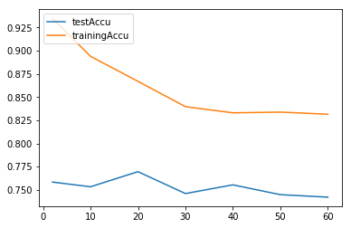

```python
# Plot a graph of test set accuracy and training set accuracy against training set percentage on the same plot.
plt.plot(percentages, testAccu)
plt.plot(percentages, trainingAccu)
plt.legend(['testAccu', 'trainingAccu'], loc='upper left')
plt.show()
```

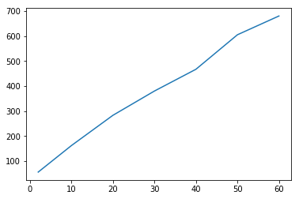

```python
# Plot another graph of number of nodes vs training set percentage.
plt.plot(percentages,nodeCounts)
plt.show()
```

### 2. Depth

Repeat the same analysis for the static-depth case (depth). (7 points) Again, consider values of training set percentage from {2%, 10%, 20%, 30%, 40%, 50%, 60%}. The validation set percentage will remain 40% for all the cases. Consider values of maximum depth from {1, 4, 7, ..., 34} and pick the best value using the validation set accuracy. The accuracies you report will be the ones for this value of maximum depth. So, for example, if the best value of maximum depth for training set 10% is 4, you will report accuracies for 10% using 4; if for 20% it is 16, you will report accuracies for 20% using 16. Plot a graph of test set accuracy and training set accuracy against training set percentage on the same plot. Plot another graph of number of nodes vs training set percentage. Finally, plot the optimal choice of depth against the training set percentage.

```python
percentages = [2, 10, 20, 30, 40, 50, 60]
depths = []
i = 1
while i <= 34:
    depths.append(i)
    i += 3
print depths
valid = 40
testAccu = []
trainingAccu = []
nodeCounts = []
depthChoice = []
for p in percentages:
    tempValidAccu = []
    tempTrainingAccu = []
    tempTestAccu = []
    tempNodeCounts = []
    for d in depths:
        decisiontree.depthHelper('adult.data','adult.test', p, 40, d)
        tempTrainingAccu.append(decisiontree.train_accu)
        tempTestAccu.append(decisiontree.test_accu)
        tempValidAccu.append(decisiontree.valid_accu)
        tempNodeCounts.append(decisiontree.nodeCount)
    maxIdx = tempValidAccu.index(max(tempValidAccu))
    trainingAccu.append(tempTrainingAccu[maxIdx])
    testAccu.append(tempTestAccu[maxIdx])
    nodeCounts.append(tempNodeCounts[maxIdx])
    depthChoice.append(depths[maxIdx])
```

```
[1, 4, 7, 10, 13, 16, 19, 22, 25, 28, 31, 34]
Training set accuracy: 0.525
Validation set accuracy: 0.49325
Test set accuracy: 0.5016
Training set accuracy: 0.59
Validation set accuracy: 0.57575
Test set accuracy: 0.5749
Training set accuracy: 0.735
Validation set accuracy: 0.674
Test set accuracy: 0.6904
Training set accuracy: 0.9
Validation set accuracy: 0.7385
Test set accuracy: 0.7534
Training set accuracy: 0.87
Validation set accuracy: 0.742
Test set accuracy: 0.7516
Training set accuracy: 0.925
Validation set accuracy: 0.74025
Test set accuracy: 0.7503
Training set accuracy: 0.945
Validation set accuracy: 0.74825
Test set accuracy: 0.7561
Training set accuracy: 0.955
Validation set accuracy: 0.74475
Test set accuracy: 0.7582
Training set accuracy: 0.935
Validation set accuracy: 0.74375
Test set accuracy: 0.7588
Training set accuracy: 0.955
Validation set accuracy: 0.747
Test set accuracy: 0.7549
Training set accuracy: 0.94
Validation set accuracy: 0.74825
Test set accuracy: 0.7588
Training set accuracy: 0.94
Validation set accuracy: 0.74525
Test set accuracy: 0.7583
Training set accuracy: 0.524
Validation set accuracy: 0.51925
Test set accuracy: 0.4935
```

[output cut: 198 more lines]

```
Training set accuracy: 0.803333333333
Validation set accuracy: 0.73
Test set accuracy: 0.7359
Training set accuracy: 0.812
Validation set accuracy: 0.73875
Test set accuracy: 0.7431
Training set accuracy: 0.819
Validation set accuracy: 0.7415
Test set accuracy: 0.7414
Training set accuracy: 0.824833333333
Validation set accuracy: 0.7475
Test set accuracy: 0.7489
Training set accuracy: 0.830833333333
Validation set accuracy: 0.74475
Test set accuracy: 0.7471
```

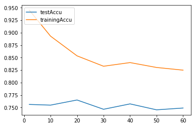

```python
# Plot a graph of test set accuracy and training set accuracy against training set percentage on the same plot.
plt.plot(percentages, testAccu)
plt.plot(percentages, trainingAccu)
plt.legend(['testAccu', 'trainingAccu'], loc='upper left')
plt.show()
```

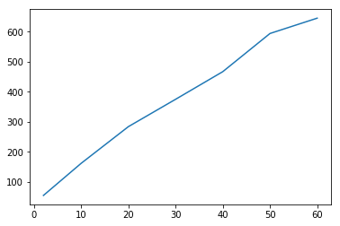

```python
# Plot another graph of number of nodes vs training set percentage.
plt.plot(percentages,nodeCounts)
plt.show()
```

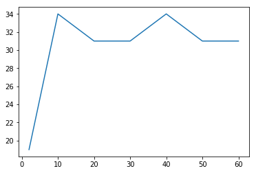

```python
# Finally, plot the optimal choice of depth against the training set percentage.
plt.plot(percentages,depthChoice)
plt.show()
```

### 3. Prune

Repeat the above analysis for the pruning case (prune). (7 points) Again, consider values of training set percentage from {2%, 10%, 20%, 30%, 40%, 50%, 60%}. The validation set percentage will remain 40% for all the cases. You will use the validation set when deciding to prune. Plot a graph of test set accuracy and training set accuracy against training set percentage on the same plot. Plot another graph of number of nodes vs training set percentage.

```python
percentages = [2, 10, 20, 30, 40, 50, 60]
valid = 40
testAccu = []
trainingAccu = []
nodeCounts = []

for p in percentages:
    decisiontree.pruneHelper('adult.data','adult.test', p, 40)
    nodeCounts.append(decisiontree.nodeCount)
    testAccu.append(decisiontree.test_accu)
    trainingAccu.append(decisiontree.train_accu)
```

```
Training set accuracy: 0.675
Test set accuracy: 0.5831
Training set accuracy: 0.707
Test set accuracy: 0.6486
Training set accuracy: 0.7365
Test set accuracy: 0.6745
Training set accuracy: 0.632
Test set accuracy: 0.5544
Training set accuracy: 0.66075
Test set accuracy: 0.6185
Training set accuracy: 0.6528
Test set accuracy: 0.6186
Training set accuracy: 0.604666666667
Test set accuracy: 0.5642
```

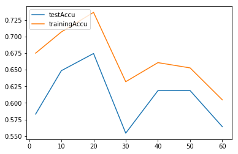

```python
# Plot a graph of test set accuracy and training set accuracy against training set percentage on the same plot.
plt.plot(percentages, testAccu)
plt.plot(percentages, trainingAccu)
plt.legend(['testAccu', 'trainingAccu'], loc='upper left')
plt.show()
```

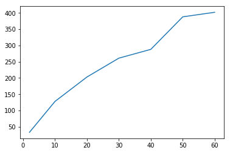

```python
# Plot another graph of number of nodes vs training set percentage.
plt.plot(percentages,nodeCounts)
plt.show()
```

### 4.

Why don’t we prune directly on the test set? Why do we use a separate validation set? (3 points)t

First of all, using testing data for pruning will 'contaminate' the pureness of the purpose of the testing data set. For example, the model will tends to perform well on testing data by adapting to perform well on it without generalizing. So, we need a seperate validation data set for us to test the performance along the pruning process while we still have untouched testing data for the final round benchmarking.

### 5.

How would you convert your decision tree (in the depth and prune cases) from a classification model to a ranking model? (4 points) That is, how would you output a ranking over the possible class labels instead of a single class label?

So, this is the question about how do we convert the absolute classification tasks like either true or false to the task that identify the probobilities for different labels.

Actually, in my implementation of this decision tree classification algorithm, it could easily adapt to the feature like ranking over the possible class labels instead of single class label because of some of the 'uncertainty' inside of the leaf node of the decision tree. For example, for some leaf nodes, it is not purely classifies as '>=50' or '<50', but a misure of both of the instances like 9/10 chance it's gonna be '>=50', and 1/10 gonna be '<50'. So in the single class label version, I just choose the highest probable answers in the leaf node and return to the decision. So, in order to make the answer lists of the ranking of possible results, we could just make the output not as a list of possible result answers instead of single highest probable result.